# Reproducible Research: Peer Assessment 1

## Loading and preprocessing the data

Get data set from the link given in the assignment:

```r
fileurl <- "https://d396qusza40orc.cloudfront.net/repdata%2Fdata%2Factivity.zip"
download.file(fileurl, destfile = "activity.zip", method="curl")
```

Extract (unzip) the downloaded activity set. This will create ‘activity.csv’ in the working directory.

```r
unzip('activity.zip', overwrite=TRUE)
```

Load the dataset into the program.

```r
data <- read.csv('activity.csv')
```

## What is mean total number of steps taken per day?

Ignore the missing values:

```r
noNAdata <- na.omit(data)
```

Sum the steps of each day:

```r
dframe<-aggregate(noNAdata$steps ~ noNAdata$date, FUN=sum, data=noNAdata)
names(dframe) <- c('date','steps')
```

### Make a histogram of the total number of steps taken each day

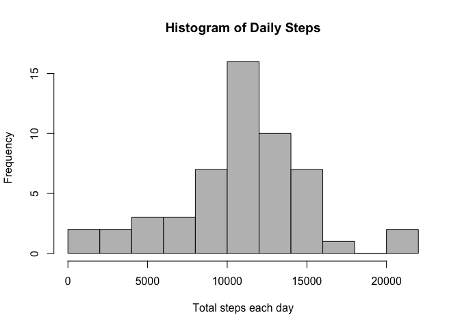

```r
hist(dframe$steps,main='Histogram of Daily Steps',xlab='Total steps each day',col='grey',breaks=15)
```

### Calculate and report the mean and median total number of steps taken per day

Mean of steps taken per day

```r
mean(dframe$steps)
```

```
## [1] 10766.19
```

Median of steps taken per day

```r
median(dframe$steps)
```

```
## [1] 10765
```

## What is the average daily activity pattern?

### Make a time series plot (i.e. type = “l”) of the 5-minute interval (x-axis) and the average number of steps taken, averaged across all days (y-axis)

Take the mean of all the steps in each interval:

```r
dapdata <- aggregate(noNAdata$steps ~ noNAdata$interval, FUN=mean, data=noNAdata)
names(dapdata) <- c('interval','steps')
```

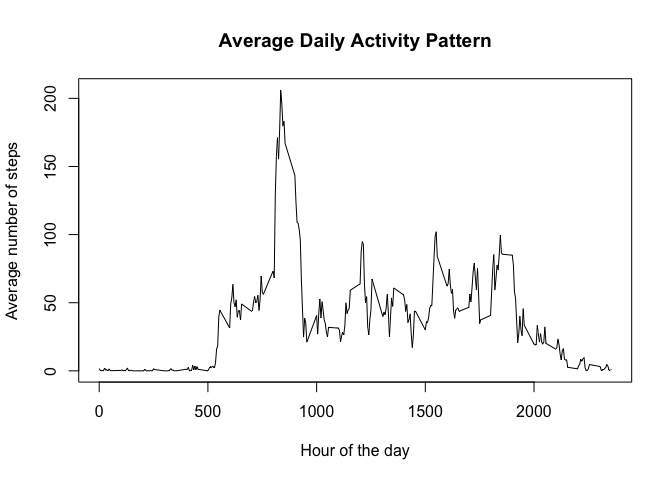

```r
plot(dapdata, type="l", main="Average Daily Activity Pattern",xlab="Hour of the day", ylab="Average number of steps")
```

### Which 5-minute interval, on average across all the days in the dataset, contains the maximum number of steps?

Find max showing its interval

```r
dapdata[which.max(dapdata$steps),]
```

```
##     interval    steps
## 104      835 206.1698
```

## Imputing missing values

### Calculate and report the total number of missing values in the dataset (i.e. the total number of rows with NAs)

Create a dataframe which lists if a missing value (NA) is found (TRUE) or not (FALSE) in each row.

```r
isnadata <- is.na(data)
```

Use summary to find all the NA’s per column

```r
summary(isnadata)
```

```
##    steps            date          interval
##  Mode :logical   Mode :logical   Mode :logical
##  FALSE:15264     FALSE:17568     FALSE:17568
##  TRUE :2304      NA's :0         NA's :0
##  NA's :0
```

There are 2304 missing values (NA) in the dataset.

### Devise a strategy for filling in all of the missing values in the dataset.

Fill all the missing values (NA) using the mean of the same interval.

### Create a new dataset that is equal to the original dataset but with the missing data filled in.

Create a for statement to go over all the rows in the dataset, find missing values and replace them with the mean value.

```r
filldata <- data

for (i in 1:nrow(filldata)){
  if (is.na(filldata$steps[i])){
    interval_val <- filldata$interval[i]
    row_id <- which(dapdata$interval == interval_val)
    steps_val <- dapdata$steps[row_id]
    filldata$steps[i] <- steps_val
  }
}
```

### Make a histogram of the total number of steps taken each day and Calculate and report the mean and median total number of steps taken per day.

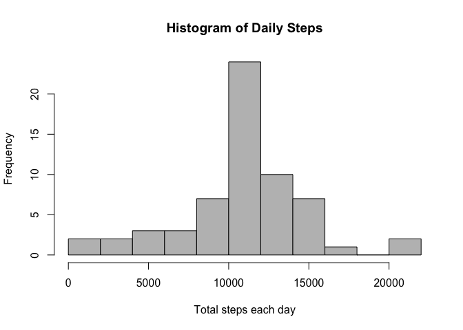

```r
dframenew<-aggregate(filldata$steps ~ filldata$date, FUN=sum, data=filldata)
names(dframenew) <- c('date','steps')
hist(dframenew$steps,main='Histogram of Daily Steps',xlab='Total steps each day',col='grey',breaks=15)
```

Mean of steps taken per day

```r
mean(dframenew$steps)
```

```
## [1] 10766.19
```

Median of steps taken per day

```r
median(dframenew$steps)
```

```
## [1] 10766.19
```

## Are there differences in activity patterns between weekdays and weekends?

For this part the weekdays() function may be of some help here. Use the dataset with the filled-in missing values for this part.

### Create a new factor variable in the dataset with two levels – “weekday” and “weekend” indicating whether a given date is a weekday or weekend day.

First, transform the dates into a Date Class:

```r
filldata$date <- as.Date(filldata$date)
```

Second, identify if the date is a weekday or weekend:

```r
filldata$weekday <- weekdays(filldata$date)
for (i in 1:nrow(filldata)){
  if (filldata$weekday[i] == 'Saturday' |filldata$weekday[i] == 'Sunday'){
    filldata$weekday[i] <- 'Weekend'
  } else {
    filldata$weekday[i] <- 'Weekday'
  }
}
filldata$weekday <- as.factor(filldata$weekday)
splitdata <- split(filldata, filldata$weekday)
weekday <- splitdata$Weekday
weekend <- splitdata$Weekend
```

### Make a panel plot containing a time series plot (i.e. type = “l”) of the 5-minute interval (x-axis) and the average number of steps taken, averaged across all weekday days or weekend days (y-axis).

Prepare data for time series

```r
dapweekdaydata <- aggregate(steps ~ interval, FUN=mean, data=weekday)
dapweekenddata <- aggregate(steps ~ interval, FUN=mean, data=weekend)
```

Plot time series of weekday and weekend

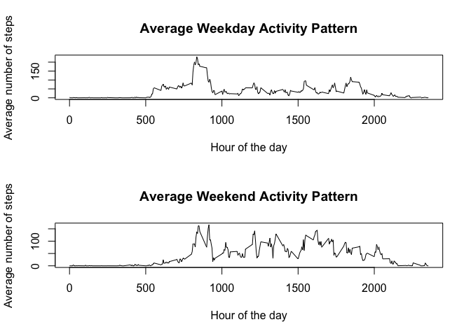

```r
par(mfrow=c(2,1))
plot(dapweekdaydata, type="l", main="Average Weekday Activity Pattern",xlab="Hour of the day", ylab="Average number of steps")
plot(dapweekenddata, type="l", main="Average Weekend Activity Pattern",xlab="Hour of the day", ylab="Average number of steps")
```